# FCM Exploratory

2024-02-14

```r
#setwd("/Users/calliestephenson/Documents/GitHub/MooreaCoralFish_CS/")
FCM <- read.csv(here("Data","CS_FCM_Plate_3_1.csv"))
FCM$sym_FSC.Events <- as.numeric(FCM$sym_FSC.Events) #don't come in as numeric for some reason?
metafcm <-read.csv(here("Data","FCM_Meta.csv"))
sa <- read.csv(here("Data","Surface_Area.csv"))
dry_wt <- read.csv(here("Data", "Wet_Dry_Weight.csv"))
Edmunds_data <- read.csv(here("Data", "Symbiont_data_published.csv"))
coral_trait_database <- read.csv(here("Data", "coral_trait_database_data.csv"))
Wes_data <- read.csv(here("Data", "Wes_sym_data.csv"))
Fox_data <- read.csv(here("Data","Fox_2021_Phys_master_Dryad.csv"))
Huffmyer_data <- read.csv(here("Data", "Huffmyer_AdultCoral_SymbiontCellCounts.csv"))
nut <- read.csv(here("Data","March_nutrients_processed.csv"))


#metafcm fixes the FCM dataframe so that is it only the good samples
metafcm <- metafcm %>%
  drop_na(SLURRY.LABEL) %>%
  mutate(Tube.Name.=sprintf("%02d-Well-%s%d", PLATE, ROW, COLUMN)) #using the sprintf() function to format a string based on a template. %02d is a placeholder for an integer (d), with a width of 2 characters, and it will be filled with the value of PLATE. -Well- is a literal string -Well- %s is a placeholder for a string (s), and it will be filled with the value of ROW. %d is a placeholder for an integer (d), and it will be filled with the value of COLUMN.
merged_FCM <- metafcm %>%
  left_join(FCM, by = "Tube.Name.") %>%
  filter(GOOD.SAMPLE)

#take only the columns we want
FCM_data <- merged_FCM[,c(1,2,6,7,13,17,21)]

#kind of annoying way I've set up these to match with sample names:
PAC <- read.csv(here("Data", "PAC_Coral_Codes.csv"))%>%
  select(!X) %>%
  select(!X.1) %>%
  rename("PLACEMENT" = "Placement_Code")
PRU <- read.csv(here("Data", "PRU_Coral_Codes.csv"))%>%
  rename("PLACEMENT" = "Placement_Code") %>%
  select(!X)
codes <- rbind(PAC[,c(2,3,4,7,8)],PRU[,c(2,3,4,7,8)])

#now to put the FCM with the coral sample names used everywhere:
FCM <- left_join(FCM_data, codes)
FCM$Cage_Uncaged <- as.factor(FCM$Cage_Uncaged)

#joining with surface area for normalizing
sa$PLACEMENT <- sa$Placement_Code
FCM <- merge(FCM, sa[, c('PLACEMENT', 'Surface_Area')], by = 'PLACEMENT') #make a joining variable
dry_wt$PLACEMENT <- dry_wt$Placement
FCM <- merge(FCM, dry_wt[c('PLACEMENT','Approximate.Dry.Weight.of.Whole.Sample')])

#These columns are to show that the FCM-generated events per ul is actually divided by total (150) volume, not the one to include
FCM$FSC.Events.per.sample.ul <- FCM$sym_FSC.Events / ((120))
FCM$Events.per.total.sample.ul <- FCM$sym_FSC.Events / 150

#So really, the question remains if the FSC.Events is only the 'include' portion, or if the FSC.Events is from the total sample
#Because why else is the machine dividing the FSC.Events by 150 (the total sample volume) to get the sym_FSC.Events.μL.V.
#Wes says that it is ONLY in the include gate
```

GREAT! Now we have the number of cells in each sample, time to upscale it to the full sample.

From the slurry I took 1 ml for FCM, from that ml I took 28 ul from the original slurry volume. This was then diluted to make a 150 uL sample that was run fast (60 uL/min) on the flow cytometer. We only used the last 120 ul (cut out 30 seconds at the beginning which is 30 uL). Assuming the 8 second mix appropriately homogenized everything, this means we used 120/150 of the sample (aka 80% of the sample).

```r
amount_of_coral_slurry_in_the_include_gate <- (28*(120/150)) #28 ul of slurry, 120 seconds/ul go in the include gate of the 150 seconds/ul total that were ran for each sample

FCM$FSC.Events.per.coralsample.ul <- FCM$sym_FSC.Events / amount_of_coral_slurry_in_the_include_gate

#Need to multiply by 50,000 (the number of ul in a 50 ml sample) to get the number of symbionts per slurry
FCM$FSC.Events.per.slurry <- FCM$FSC.Events.per.coralsample.ul * FCM$ORIGINAL.SLURRY.VOLUME * 1000 #og slurry volume is in ml, convert to ul to ml with *1000

#Now, normalizing that to the amount of live surface area that I airbrushed per coral:
FCM$FSC.Events_per_cm_2 <- FCM$FSC.Events.per.slurry / FCM$Surface_Area

#Now, normalizing to the dry weight of the coral sample
FCM$FSC.Events_per_g_dry_weight <- FCM$FSC.Events.per.slurry / FCM$Approximate.Dry.Weight.of.Whole.Sample

#write_csv(FCM, here("Data","FCM_Tidy.csv"))
```

Ok, now that it is normalized, we can combine it with nutrient data

```r
#suppressed the warning "Detected an unexpected many-to-many relationship between `x` and `y`" because we have a lot of the nutrient metrics for each pin
FCM$CowTagID <- paste0("V",FCM$Pin_Number) #make a joining variable for this and nutrient data
all_data <- left_join(FCM, nut, by="CowTagID")  #join them
all_data <- drop_na(all_data)
```

#### Data Exploration:

Looking for any outliers

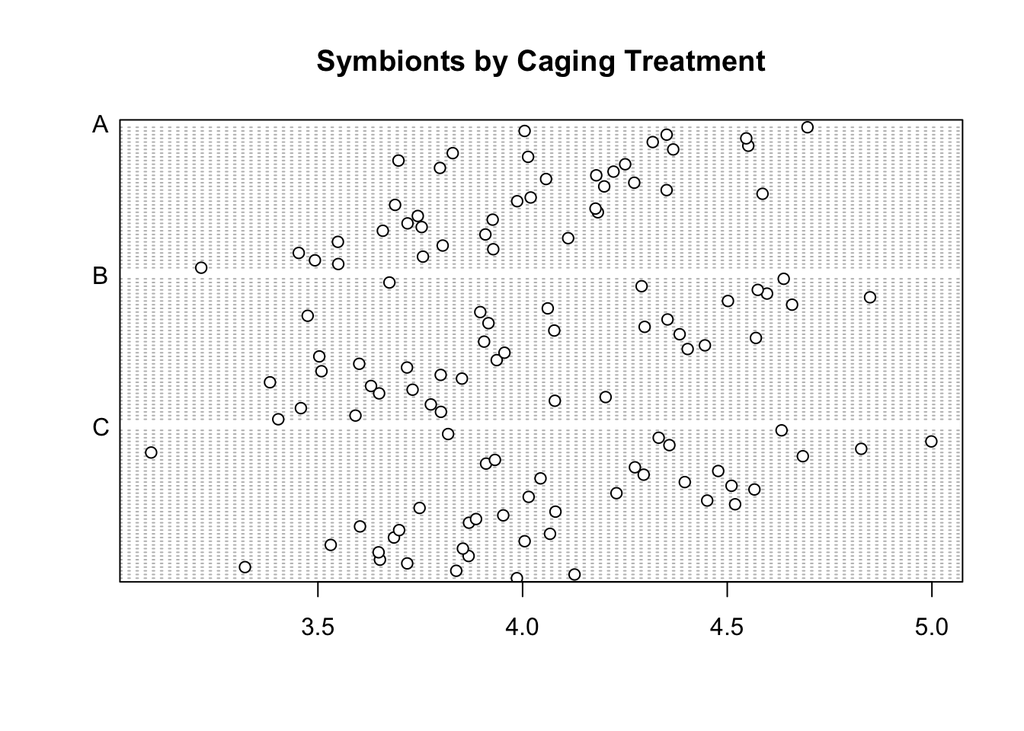

```r
FCM$Cage_Uncaged <- as.factor(FCM$Cage_Uncaged)
dotchart(log10(FCM$FSC.Events_per_cm_2), main = "Symbionts by Caging Treatment", groups = FCM$Cage_Uncaged)
```

Fig 1. Log-Scaled number of symbionts by coral surface area (Front scatter events per $cm^2$)

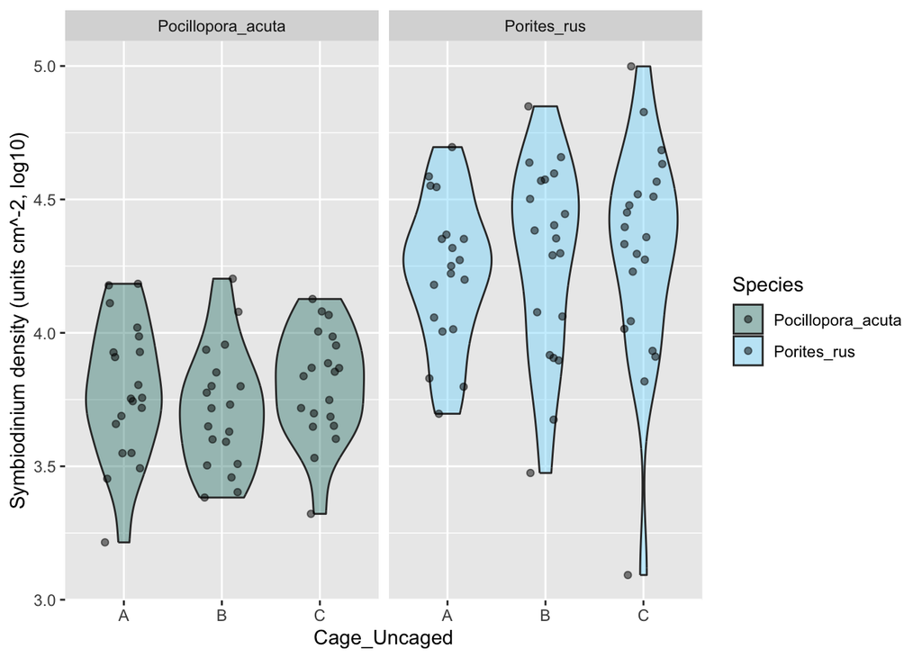

```r
ggplot(FCM, aes(x = Cage_Uncaged, y = log10(FSC.Events_per_cm_2), fill = Species)) +
  geom_violin() +
  geom_jitter(width = 0.2, height = 0, alpha = 0.5) +  # Adding jitter
  scale_fill_fish_d(option = "Acanthurus_olivaceus", alpha = 0.4, begin = 0.3, end = 1)+
  facet_wrap(~Species)+
  ylab("Symbiodinium density (units cm^-2, log10)")
```

Fig 2. Number of symbionts by coral surface area (Front scatter events per $cm^2$)

#### Same figures but per g dry weight

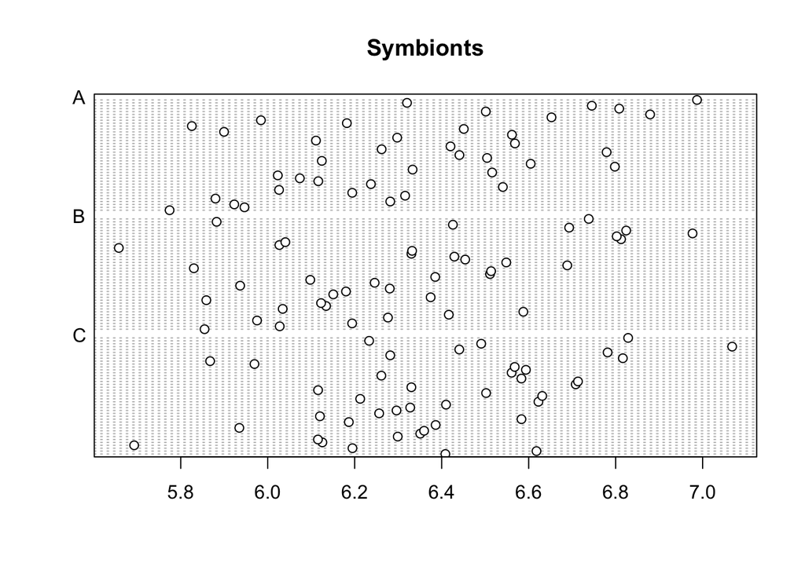

```r
dotchart(log10(FCM$FSC.Events_per_g_dry_weight), main = "Symbionts", groups = FCM$Cage_Uncaged)
```

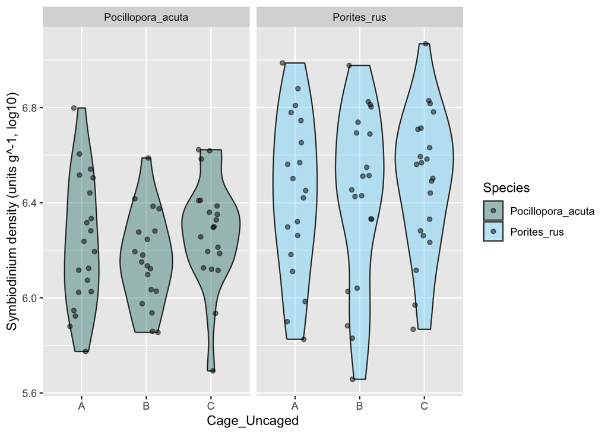

```r
ggplot(FCM, aes(x = Cage_Uncaged, y = log10(FSC.Events_per_g_dry_weight), fill = Species)) +
  geom_violin() +
  geom_jitter(width = 0.2, height = 0, alpha = 0.5) +  # Adding jitter
  scale_fill_fish_d(option = "Acanthurus_olivaceus", alpha = 0.4, begin = 0.3, end = 1)+
  facet_wrap(~Species)+
  ylab("Symbiodinium density (units g^-1, log10)")
```

### Comparing against published data:

Gotta tidy it up a bit:

```r
#for comparing against publicly-available data, need to join data
Edmunds_data$species <- paste(Edmunds_data$Genus, Edmunds_data$Species, sep = " ")
Edmunds_data$Species <- Edmunds_data$species
Edmunds_data <- Edmunds_data[,c(4,5,18,20)]
Edmunds_data <- Edmunds_data %>%
  filter(Trait == "Symbiodinium density") %>%
  filter(Species %in% c("Porites rus", "Pocillopora damicornis"))
Edmunds_data$FSC.Events_per_cm_2 <- Edmunds_data$Value
Edmunds_data <- Edmunds_data[,c("Species", "FSC.Events_per_cm_2")]
Edmunds_data$Source <- "Edmunds et al., 2014"

#I went looking for more data from the coral trait database, but it only had the same data as the Edmunds paper:
coral_trait_database <- coral_trait_database[,c("specie_name", "trait_name", "methodology_name","value")] %>%
  rename("Species" = "specie_name", "Value" = "value")
coral_trait_database <- coral_trait_database%>%
  filter(trait_name == "Symbiodinium density") %>%
  filter(Species %in% c("Porites rus", "Pocillopora damicornis", "Pocillopora acuta"))
#STOPPING BC IDENTICAL DATA

##Time to try wes data
#Remember to subset Collection_Bleaching_Level1=="HE" to select only the healthy samples, then you can visualize either "sym.SA" or "log10.sym.SA".
Wes_data <- Wes_data[,c("Species", "sym.SA", "Collection_Bleaching_Level1")] %>%
  filter(Collection_Bleaching_Level1 == "HE") %>%
  filter(Species == "Porites rus")
Wes_data$FSC.Events_per_cm_2 <- Wes_data$sym.SA
Wes_data <- Wes_data[,c("Species", "FSC.Events_per_cm_2")]
Wes_data$Source <- "Sparagon et al., 2024"

#Add in Fox data
Fox_data$Species <- ifelse(Fox_data$Species == "POC", "Pocillopora acuta", Fox_data$Species)
Fox_data <- Fox_data %>%
  filter(Species == "Pocillopora acuta")
Fox_data$FSC.Events_per_cm_2 <- Fox_data$Zoox.cm2
Fox_data <- Fox_data[,c("Species","FSC.Events_per_cm_2")]
Fox_data$Source <- "Fox et al., 2021"

#And Huffmyer data
Huffmyer_data$Species <- ifelse(Huffmyer_data$Species == "PACU", "Pocillopora acuta", Huffmyer_data$Species)
Huffmyer_data <- Huffmyer_data %>%
  filter(Species == "Pocillopora acuta")
Huffmyer_data$FSC.Events_per_cm_2 <- Huffmyer_data$Symbionts.cm2
Huffmyer_data <- Huffmyer_data[,c("Species","FSC.Events_per_cm_2")]
Huffmyer_data$Source <- "Huffmyer et al., 2020"

#
pub_data <- rbind(Edmunds_data, Wes_data, Fox_data)
pub_data$origin <- "Published Data"
```

Now that it should all be tidy, let’s plot:

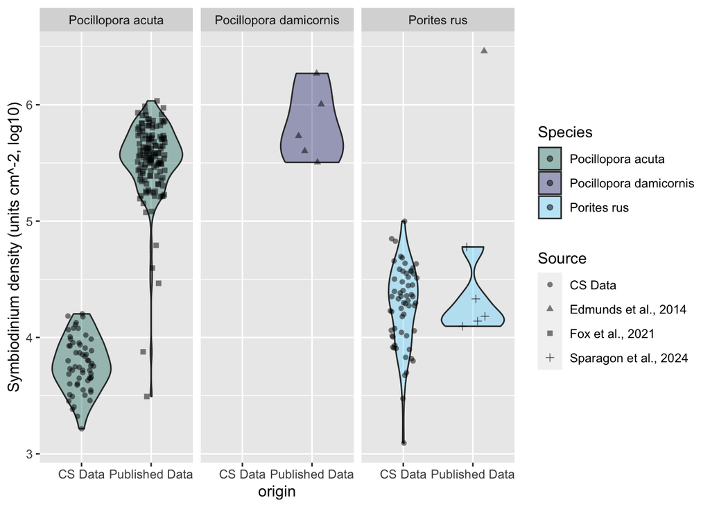

```r
pvmmine <- FCM[,c("Species", "FSC.Events_per_cm_2")]
pvmmine$origin <- "CS Data"
pvmmine$Source <- "CS Data"
pub_vs_mine <- rbind(pvmmine,pub_data)
pub_vs_mine$Species <- gsub("Porites_rus", "Porites rus", pub_vs_mine$Species)
pub_vs_mine$Species <- gsub("Pocillopora_acuta", "Pocillopora acuta", pub_vs_mine$Species)

ggplot(pub_vs_mine, aes(x = origin, y = log10(FSC.Events_per_cm_2), fill = Species, shape = Source)) +
  geom_violin() +
  geom_jitter(width = 0.2, height = 0, alpha = 0.5) +  # Adding jitter
  scale_fill_fish_d(option = "Acanthurus_olivaceus", alpha = 0.4, begin = 0.3, end = 1) +
  facet_wrap(~Species) +
  ylab("Symbiodinium density (units cm^-2, log10)")
```

### Models!

Let’s start with seeing if caging had any effect on the corals

```r
PRUcagemodel <- lmer(log10(FSC.Events_per_cm_2) ~ Cage_Uncaged + (1 | Genotype),
         data= FCM %>%
           filter(Species=="Porites_rus"))
Anova(PRUcagemodel)
```

```
## Analysis of Deviance Table (Type II Wald chisquare tests)
##
## Response: log10(FSC.Events_per_cm_2)
##               Chisq Df Pr(>Chisq)
## Cage_Uncaged 0.4613  2      0.794
```

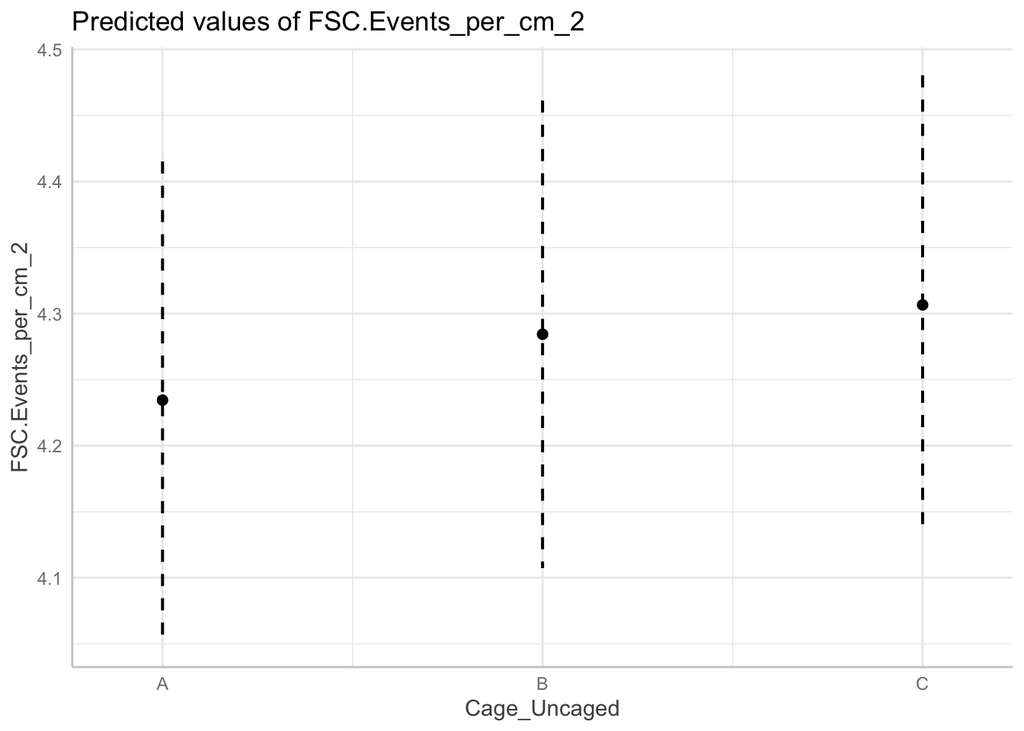

```r
#ggcoef_model(PRUcagemodel)#I just don't love ggcoef for this kind bc it takes away se on A
ggeffect(PRUcagemodel) %>% plot()
```

```r
#adding data to this breaks it somehow:
#ggeffect(PRUcagemodel) %>%
#  plot(add.data = TRUE, alpha=0.01, jitter = TRUE, color = "darkblue")
```

```r
PACcagemodel <- lm(log10(FSC.Events_per_cm_2) ~ Cage_Uncaged,
         data= FCM %>%
           filter(Species=="Pocillopora_acuta"))
Anova(PACcagemodel)
```

```
## Anova Table (Type II tests)
##
## Response: log10(FSC.Events_per_cm_2)
##               Sum Sq Df F value Pr(>F)
## Cage_Uncaged 0.08797  2  0.8359 0.4388
## Residuals    2.94683 56
```

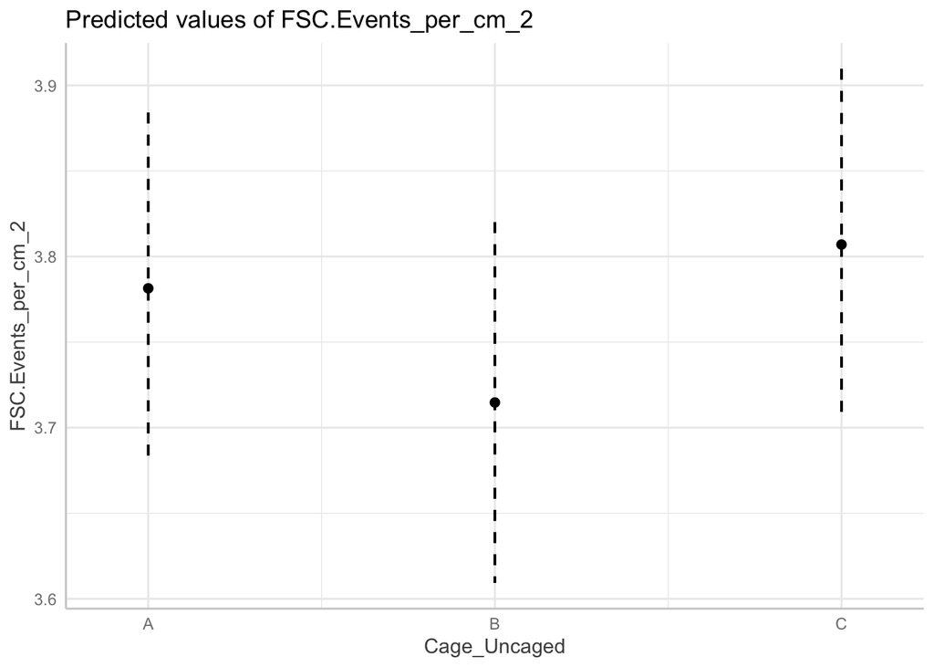

```r
#ggcoef_model(PACcagemodel) #I just don't love ggcoef for this kind bc it takes away se on A
ggeffect(PACcagemodel) %>% plot()
```

So it looks like caging didn’t make a big difference for either species symbiont counts. This is really interesting to me, as I’d expect the rus to have responded to the intense munching, but apparently not.

#### Example ANCOVA

```r
nut <- read.csv(here("Data","March_nutrients_processed.csv"))
FCM$CowTagID <- paste0("V",FCM$Pin_Number) #make a joining variable
all_data <- left_join(FCM, nut, by="CowTagID")  #join them
all_data <- drop_na(all_data)
gg_data <- all_data %>%
  filter(Parameters == "Phosphate_umolL")
```

```r
m1 <- lm(FSC.Events_per_g_dry_weight ~ log(Maximum),
         data= all_data %>%
           filter(Parameters=="Silicate_umolL", Species=="Porites_rus"))
Anova(m1)
```

```
## Anova Table (Type II tests)
##
## Response: FSC.Events_per_g_dry_weight
##                  Sum Sq Df F value Pr(>F)
## log(Maximum) 1.5262e+12  1  0.2498 0.6191
## Residuals    3.5440e+14 58
```

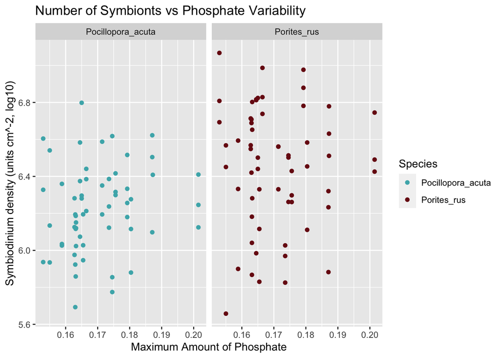

```r
ggplot(gg_data, aes(x = Maximum, y = log10(FSC.Events_per_g_dry_weight),)) +
  geom_point(aes(color=Species)) +  # Add points
  scale_color_fish_d(option = "Trimma_lantana") +
  facet_wrap(~Species)+
  labs(title = "Number of Symbionts vs Phosphate Variability",
       x = "Maximum Amount of Phosphate",
       y = "Symbiodinium density (units cm^-2, log10)")
```